# Simulating Data from a DAG with Network Dependencies

Robin Denz

# Introduction

Most algorithms used to generate artificial data based on DAGs do so using the classic assumption that all individual observations are independently and identically distributed (the classic i.i.d. assumption). This is done for multiple reasons. First, it makes the specification of the data generation process (DGP) a lot easier: distributions and structural equations can be defined once for the entire DGP and used to generate arbitrarily large amounts of data. Secondly, artificial DAG based data is most often used in simulation studies or other contexts in which statistical models are applied to them. Since most of these models require the i.i.d. assumption, it makes sense to generate data this way.

This is, however, not the case for all applications. For example, the spread of an infectious disease is dependent on how “connected” the population at risk is (Danon et al. 2011). An individual with many contacts will usually have a higher probability of coming into contact with an infected person and thus will have a higher chance of getting infected as well. This fact is in direct opposition to the i.i.d. assumption, because the infection status of one individual influences the infection status of other individuals. The individuals are said to “interfere” with each other (VanderWeele and An 2013). Networks-based simulations are one way to model such dependencies.

The following vignette introduces this methodology and how it is implemented in the `simDAG` R package (Denz and Timmesfeld 2026). This is an advanced topic. We assume that the reader is already familiar with the general `simDAG` syntax and DAG based simulations. Please consult the associated paper or the numerous other vignettes first, if this is not the case.

```r
library(data.table)
library(igraph)
library(simDAG)
```

# What are networks-based simulations?

In a networks-based simulation, each individual is embedded in one or multiple networks. These networks may have an arbitrary amount of connections between the individuals, signifying who is connected to who. Data may then be simulated using the essentially the same approach that is used in classic DAG-based simulations, with the added possibility of using the network structures to define individual dependencies. For example, a variable could then be defined not only as a function of other variables, but also as a function of the neighbors of an individual $i$ (and their variable values), where neighbors are defined as any individual $j$ that share some connection with $i$ in a given network (although in directed networks, multiple options to define neighbors are possible). A more rigorous explanation, along with an explanation of their implementation of the methodology in the `simcausal` package, is given by Sofrygin, Neugebauer, and van der Laan (2017).

In network science, the points in a networks are often called *nodes* or *vertices*, while the connections between them are usually called *edges* or, in directed networks, *arrows*. When talking about networks I will stick to the terms *vertices* and *edges* here, to avoid confusion with the terms *nodes* and *arrows* that are also used when talking about DAGs. Note that a DAG is of course also a special type of network, but it serves a different purpose here. In the simulations described here, the DAG defines the causal relationships between variables, while the network describes connections between individuals.

# Networks in regular simulations

## A single network

We will start with a simple example, using only a single un-directed, un-weighted, static network that never changes and only a few variables that are also constant over time.

Consider the following simple network:

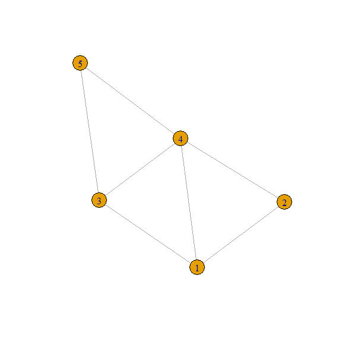

```r
set.seed(1234)

data <- data.frame(from=c(1, 1, 2, 3, 4, 5, 5),
                   to=c(2, 3, 4, 4, 1, 3, 4))

g <- graph_from_data_frame(data, directed=FALSE)
plot(g)
```

In this network, individual $1$ has three neighbors: $2, 3$ and $4$, while individual $5$ only has two neighbors: $3$ and $4$. We will first simulate `age` and `sex` values for all of these individuals, irrespective of their position in the network, using the standard `simDAG` syntax to generate data from a `DAG`:

```r
dag <- empty_dag() +
  node("age", type="rnorm", mean=50, sd=10) +
  node("sex", type="rbernoulli", p=0.5, output="numeric")
```

Here, `age` and `sex` are both root nodes, with `age` being a normally distributed variable with mean 50 and standard deviation of 10 and `sex` being Bernoulli distributed with equal probabilities of being either male (`sex = 0`) or female (`sex = 1`). Now every person has assigned values. If we generated the data right now, without further nodes, it would look like this:

```r
set.seed(5245)
data <- sim_from_dag(dag, n_sim=5)
print(data, row.names=TRUE)
```

```
#>         age   sex
#>       <num> <num>
#> 1: 35.08209     1
#> 2: 47.01248     1
#> 3: 35.42111     0
#> 4: 57.29242     0
#> 5: 43.33519     0
```

The rownames of this `data.table` show to which person each value belongs. In other words, row 1 will be mapped to vertex 1 in the network, row 2 will be mapped to vertex 2 of the network and so on. To impose the network structure onto this `DAG`, we can simply add the already generated `igraph` object to it using the `network()` function:

```r
dag <- dag + network("network1", net=g)
```

In this `network()` call, all we had to do was provide a `name` for the network (here called `network1`) and the network itself, for which we used the `igraph` object. Note that, because the graph is pre-generated with only 5 individuals in it, this DAG can now only generate data for 5 individuals as well when actually using this network. To allow flexible changes of `n_sim` when calling `sim_from_dag()` or `sim_discrete_time()` later on, users need to supply a function instead, which we will show later. For now we stay with the 5 individuals.

Now that the network is added, we are able to use `net()` syntax in the `formula` argument of any further nodes. For example, we could define a new variable called `infected`, which should contain an indicator of whether someone is infected with some infectious disease or not, as a function of the persons own `age` and `sex` *and* as a function of their neighbors `age` and `sex` using the following syntax:

```r
dag <- dag + node("infected", type="binomial",
                  formula= ~ 5 + age*0.1 + sex*-0.5 +
                    net(mean(age))*-0.2 + net(mean(sex))*-0.4)
```

In this node, the infection probability increase with the persons own `age`, is higher for males, decreases with higher mean ages of the persons neighbors and decreases with higher proportions of females among a persons neighbors. If we run the simulation again with this updated DGP, the results looks like this:

```r
set.seed(5245)
data <- sim_from_dag(dag, n_sim=5)
print(data, row.names=TRUE)
```

```
#>         age   sex infected
#>       <num> <num>   <lgcl>
#> 1: 35.08209     1    FALSE
#> 2: 47.01248     1    FALSE
#> 3: 35.42111     0    FALSE
#> 4: 57.29242     0     TRUE
#> 5: 43.33519     0     TRUE
```

Note that the intermediate variables (mean age of neighbors, proportion of female neighbors) are not included in this output. Users may use nodes of type `"identity"` to actually save and inspect the output of `net()` calls instead. For example, calculating the number of infected neighbors per person could now be done using:

```r
dag <- dag + node("n_inf_neighbors", type="identity",
                  formula= ~ net(sum(infected)), kind="data")

set.seed(5245)
data <- sim_from_dag(dag, n_sim=5)
print(data, row.names=TRUE)
```

```
#>         age   sex infected n_inf_neighbors
#>       <num> <num>   <lgcl>           <num>
#> 1: 35.08209     1    FALSE               1
#> 2: 47.01248     1    FALSE               1
#> 3: 35.42111     0    FALSE               2
#> 4: 57.29242     0     TRUE               1
#> 5: 43.33519     0     TRUE               1
```

This may be useful to inspect if the aggregation worked or to save some computation time when the same `net()` call is used in multiple subsequent nodes. In this example, individuals 4 and 5 are infected, which means that individuals 1, 2 and 4 and 5 each have one infected neighbor, while individual 3 has 2 infected neighbors because it has a connection to both individuals 4 and 5.

## Multiple networks

In reality, individuals are usually embedded in more than one network at the same time. People are part of friendship networks, contact networks, professional networks and so on. This is also directly supported by the `simDAG` package. All we have to do is add multiple networks to the `DAG`. Below we first generate two random networks of the same size (20 individuals) using the `igraph` package:

```r
set.seed(56356)
g1 <- igraph::sample_gnm(n=20, m=30)
g2 <- igraph::sample_gnm(n=20, m=30)

V(g1)$color <- "salmon"
V(g2)$color <- "lightblue"
```

Suppose that the first network is a “friendship network”, showing who is friends with who and the second is a “professional network”, showing who works with who. They look like this:

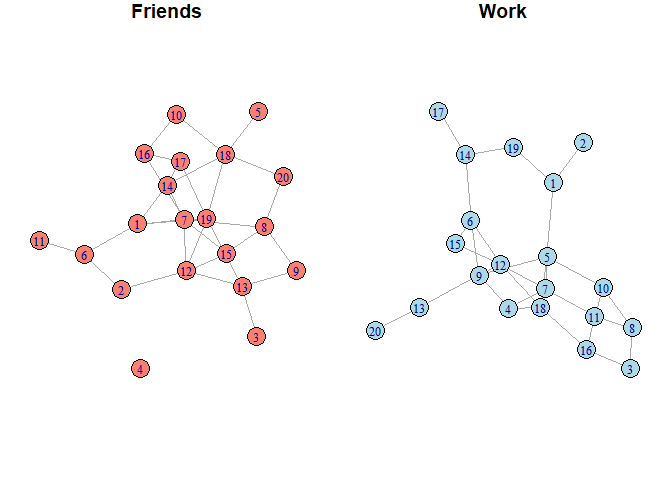

```r
par(mfrow=c(1, 2), mar=c(0, 0, 0, 0) + 1)

plot(g1, main="Friends", margin=0, vertex.label.cex=0.8)
plot(g2, main="Work", margin=0, vertex.label.cex=0.8)
```

We colored the vertices differently to highlight that they are two distinct networks. We now first repeat large parts of the `DAG` from earlier, but add both networks to it this time:

```r
dag <- empty_dag() +
  node("age", type="rnorm", mean=50, sd=10) +
  node("sex", type="rbernoulli", p=0.5, output="numeric") +
  network("friends", net=g1) +
  network("work", net=g2)
```

We can now add a new node to this `DAG`, that utilizes both network dependencies at the same time:

```r
dag <- dag + node("infected", type="binomial",
                  formula= ~ 3 + age*0.1 + sex*-0.5 +
                    net(mean(age), net="friends")*-0.2 +
                    net(mean(sex), net="work")*-0.4)
```

This is exactly the same node definition of the previous example, with the only difference being that the mean `age` of the `friends` network is used and the proportion of females is used only for the `work` network. The results look like this:

```r
data <- sim_from_dag(dag, n_sim=20)
head(data, row.names=TRUE)
```

```
#>         age   sex infected
#>       <num> <num>   <lgcl>
#> 1: 53.86490     0    FALSE
#> 2: 46.69516     0    FALSE
#> 3: 33.77426     0     TRUE
#> 4: 49.78544     1       NA
#> 5: 58.56361     0    FALSE
#> 6: 66.37300     0    FALSE
```

Interestingly, individual 4 has a value of `NA` in the `infected` node. The reason for this is that individual 4 does not have any friends (don’t worry, she is not real so she can’t be sad about this) and thus the `mean(age)` call is not defined for this person. To replace such `NA` values with some other values, the `na` argument of `net()` may be used.

## Weighted networks

In many applications in network science, the edges of networks are said to have *weights*, to specify that some connections are stronger than others. In the friendship network from earlier, the weights could for example indicate that one friendship is closer than another one. Using such weights is also directly supported for simulation purposes in this package. Let us first add some random weights to the friendships from the network shown above. Re-plotting this network one can see that the edges now have different weights:

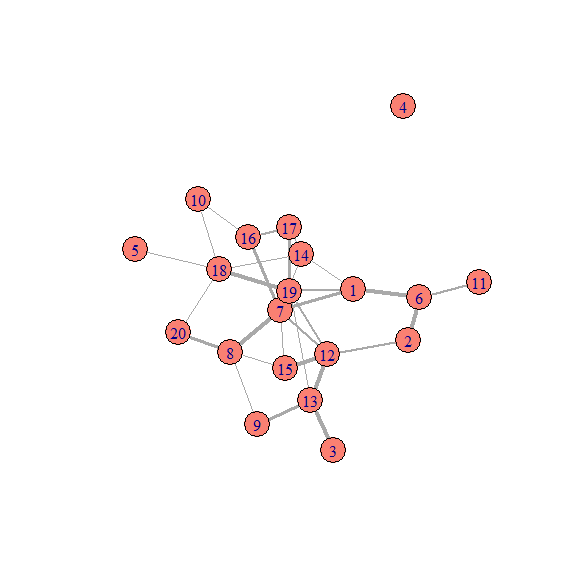

```r
E(g1)$weight <- runif(n=length(E(g1)), min=1, max=5)
plot(g1, edge.width=E(g1)$weight)
```

Regular `net()` calls will ignore these weights, if not specifically told not to. Users should use the internal `..weight..` variable to use the weights. For example, if we want to re-use the DAG definition from earlier, we could do something like this:

```r
dag <- empty_dag() +
  network("friends", net=g1) +
  node("age", type="rnorm", mean=50, sd=10) +
  node("sex", type="rbernoulli", p=0.5, output="numeric") +
  node("infected", type="binomial",
       formula= ~ 3 + age*0.1 + sex*-0.5 +
                  net(weighted.mean(x=age, w=..weight..))*-0.2 +
                  net(weighted.mean(x=sex, w=..weight..))*-0.4)
data <- sim_from_dag(dag, n_sim=20)
head(data)
```

```
#>         age   sex infected
#>       <num> <num>   <lgcl>
#> 1: 45.69134     1    FALSE
#> 2: 37.05165     0    FALSE
#> 3: 66.75057     1    FALSE
#> 4: 36.75051     1       NA
#> 5: 61.50802     0     TRUE
#> 6: 63.68616     0     TRUE
```

It is essentially the same code as before, with the only difference being that we use `weighted.mean()` instead of `mean()` to summarize the neighbors’ values and use the edge weights within this function call, giving stronger connections more weight. Users are of course free to use the `..weight..` variable in any other way as well.

## Directed Networks

So far we have always assumed that all connections in a graph are *un-directed*, e.g. that once there is an edge between vertices $1$ and $2$, that they have a reciprocal relationship with each other. In real networks it is often the case that relationships between vertices are not reciprocal, but directed. For example, in the professional network we might be interested in showing who is giving who orders. This could be done by using a *directed* network. These kinds of networks are also directly supported for simulation purposes in this package.

Let us create a random directed network first:

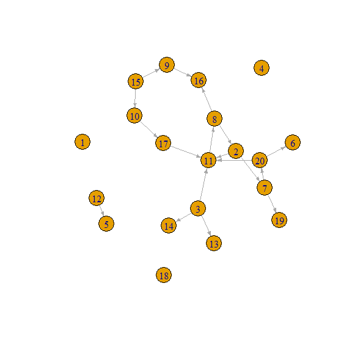

```r
set.seed(123)

g <- sample_gnm(n=20, m=18, directed=TRUE, loops=FALSE)
plot(g, edge.arrow.size=0.4)
```

In this example, individual 3 can give orders to individual 11, 13 and 14, but cannot be given orders by these individuals. Now lets suppose we want to only use the values of subordinates (e.g. vertices connected by outgoing edges) to define neighborhoods. This can be achieved using the `mode` argument of the `net()` function. We again replicate the `DAG` from earlier, changing it only slightly:

```r
dag <- empty_dag() +
  network("work", net=g) +
  node("age", type="rnorm", mean=50, sd=10) +
  node("sex", type="rbernoulli", p=0.5, output="numeric") +
  node("infected", type="binomial",
       formula= ~ 3 + age*0.1 + sex*-0.5 +
                  net(mean(age), mode="out", na=0)*-0.2 +
                  net(mean(sex), mode="out", na=0)*-0.4)
data <- sim_from_dag(dag, n_sim=20)
head(data)
```

```
#>         age   sex infected
#>       <num> <num>   <lgcl>
#> 1: 53.22599     1     TRUE
#> 2: 52.17259     1    FALSE
#> 3: 54.58468     0    FALSE
#> 4: 46.99742     0     TRUE
#> 5: 33.19981     0     TRUE
#> 6: 33.78001     1     TRUE
```

Conversely, if we want to only model the `infected` probability as a function of the “bosses” of a node (e.g. the incoming edges), all we would have to do is set `mode="in"` in the `net()` calls. If we want to disregard the edge directions, we could simply keep the `mode` argument at its default value of `"all"`. Since the way the edges are treated is defined using `net()` calls, it is of course also possible to use mixtures of these strategies in the same node definition, by using multiple `net()` calls with different `mode`s. This could also be combined with weights (as described in the previous section).

## Neighborhood order

In all previous examples, we only used the immediate neighbors of a node in our `net()` calls. By using the `order` argument of the `net()` function, it is also possible to use larger neighborhoods, meaning that instead of only considering the directly connected individuals as neighbors, we may also include individuals that are connected to those and so on. Below we show another random network where the neighbors of node 11 (colored in green) are colored in salmon for two different values of `order`:

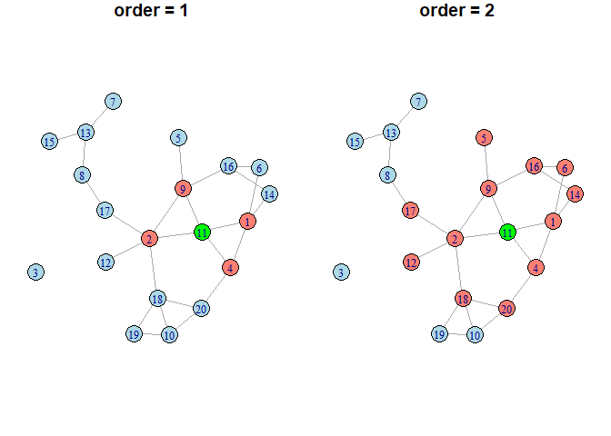

If this was a directed network, the neighborhood would of course also be dependent on the direction of the edges, as described in the previous section. Below is a simple example on how one could use this functionality:

```r
set.seed(2134)
g <- sample_gnm(n=20, m=15)

dag <- empty_dag() +
  network("net1", net=g) +
  node("age", type="rnorm", mean=50, sd=10) +
  node("sex", type="rbernoulli", p=0.5, output="numeric") +
  node("infected", type="binomial",
       formula= ~ 3 + age*0.1 + sex*-0.5 +
                  net(mean(age), order=1, na=0)*-0.2 +
                  net(mean(sex), order=2, na=0)*-0.4)
data <- sim_from_dag(dag, n_sim=20)
head(data)
```

```
#>         age   sex infected
#>       <num> <num>   <lgcl>
#> 1: 57.71886     1     TRUE
#> 2: 53.62951     0     TRUE
#> 3: 61.21526     1     TRUE
#> 4: 57.20119     1    FALSE
#> 5: 30.44710     0    FALSE
#> 6: 45.28895     0    FALSE
```

Here, we largely replicated the DAG from earlier, but use different order neighborhoods for the effect of `age` and `sex`. Again, because the `order` is defined by individual `net()` calls, users may use different values of `order` in the same node definition without any issues. Note that when using `order > 1` all edge weights are ignored, because it is not clear what the edge weight should be when considering indirect connections.

We could also go an additional step further and *only* consider the direct connections to neighbors as neighbors, without using the direct connections themselves. This can be done using the `mindist` argument of `net()`. Below is another graph illustrating the difference of using `mindist=1` and `mindist=2` with `order=2` given the earlier network:

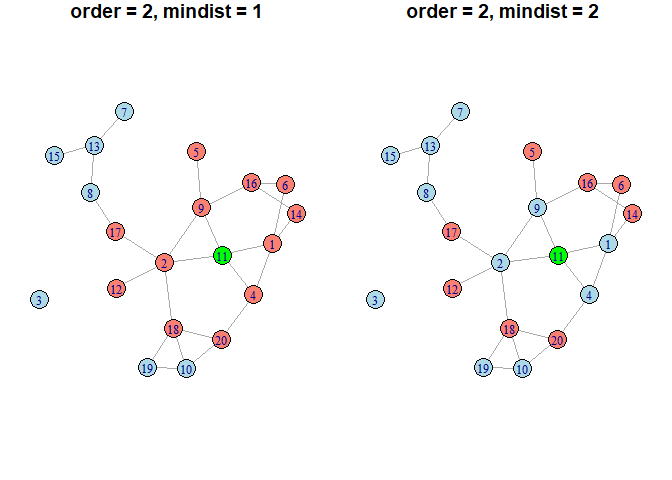

This might be useful to model extended network effects as direct effects in a `DAG`. Repeating the `DAG` from earlier (with some slight changes) we could use something like:

```r
set.seed(2134)
g <- sample_gnm(n=20, m=15)

dag <- empty_dag() +
  network("net1", net=g) +
  node("age", type="rnorm", mean=50, sd=10) +
  node("sex", type="rbernoulli", p=0.5, output="numeric") +
  node("infected", type="binomial",
       formula= ~ 3 + age*0.1 + sex*-0.5 +
                  net(mean(age), order=2, mindist=2, na=0)*-0.4)
data <- sim_from_dag(dag, n_sim=20)
head(data)
```

```
#>         age   sex infected
#>       <num> <num>   <lgcl>
#> 1: 57.71886     1     TRUE
#> 2: 53.62951     0    FALSE
#> 3: 61.21526     1     TRUE
#> 4: 57.20119     1    FALSE
#> 5: 30.44710     0    FALSE
#> 6: 45.28895     0    FALSE
```

## Networks as a function of other variables

Up to this point we have always created the networks completely independently from all other variables, which in reality could be considered unrealistic. Luckily, networks may also be defined as a function of already generated variables as well. Similar to regular `node()` function calls, it is possible to use the `parents` argument to specify that a network is based on values of the `parents`. The `data` of the `parents` is then automatically passed to the `data` argument of the function that should be used to create the network, allowing all kinds of dependencies to be implemented by the user.

Suppose that the goal is to generate data for both males and females. For some reason there should be essentially separate networks for males and females. This might for example arise when considering networks in sports that are separated by sex. To simulate such an example, we first define some functions:

```r
is_different_sex <- function(g, x) {
  V(g)[ends(g, x)[1]]$type != V(g)[ends(g, x)[2]]$type
}

gen_network <- function(n_sim, data) {
  g <- sample_gnm(n=n_sim, m=50)
  V(g)$type <- data$sex
  g <- delete_edges(g, which(vapply(E(g), is_different_sex,
                                    FUN.VALUE=logical(1), g=g)))
  return(g)
}
```

Here the `is_different_sex()` function simply takes in an edge of the graph and checks whether both vertices have the same type. The `gen_network()` function first generates a random graph and then adds the `sex` contained in the supplied `data` as a type to each node. It then deletes all edges where the type (e.g. `sex`) of the vertices is not the same. We can incorporate this into a `DAG` using:

```r
dag <- empty_dag() +
  node("age", type="rnorm", mean=25, sd=5) +
  node("sex", type="rbernoulli", p=0.5) +
  network("network1", net=gen_network, parents="sex") +
  node("infected", type="binomial", formula= ~ 1 + net(mean(age))*0.5)
```

We can now simulate from this `DAG`:

```r
set.seed(1324)
data <- sim_from_dag(dag, n_sim=20, return_networks=TRUE)
head(data$data)
```

```
#>         age    sex infected
#>       <num> <lgcl>   <lgcl>
#> 1: 17.74261   TRUE     TRUE
#> 2: 33.84116  FALSE     TRUE
#> 3: 17.13370   TRUE     TRUE
#> 4: 13.14236   TRUE     TRUE
#> 5: 33.44052   TRUE     TRUE
#> 6: 21.95168   TRUE       NA
```

Note that we set `return_networks=TRUE`, so that we can also inspect the generated network. Whenever this is done, the `sim_from_dag()` function actually returns a list containing both the generated `data` and the `networks`. Below is the generated networks, with different vertex colors for each `sex`:

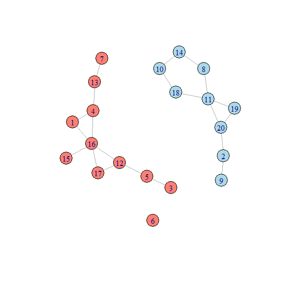

```r
g <- data$networks$network1$net
V(g)$color <- ifelse(V(g)$type, "salmon", "lightblue")
plot(g)
```

This is a fairly artificial example, because it is only meant to illustrate this functionality in a simple way. Users could of course use this in much more interesting ways. Because the `net` argument allows any function, there are no limits set to how the network structure should be dependent on the `data` at hand.

# Networks in discrete-time simulation

It is of course also possible to use the outlined networks-simulation-based approach in discrete-time simulations conducted using the `sim_discrete_time()` function. Below we illustrate how to do this using both static and dynamically changing networks.

## Static networks

As a simple example, we will consider the spread of an infectious disease through a (un-directed and un-weighted) network of 18 individuals and 6 distinct points in time. In this simulation, there is only one variable of interest: the infection status of a person, denoted by `infected` (0 = not infected, 1 = infected). First, we will generate a random graph of 18 individuals with 30 connections between them using the `igraph` package:

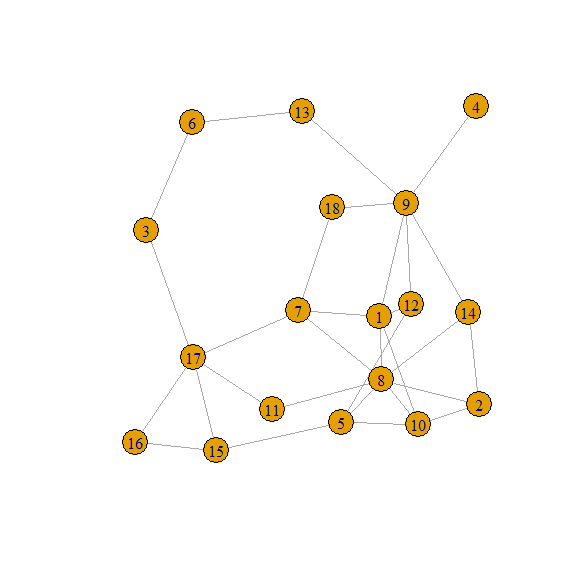

```r
set.seed(244368)
g2 <- igraph::sample_gnm(n=18, m=30)

plot(g2)
```

with $k$ being the number of infected neighbors of the individual. Additionally, once infected, a person stays infected. We can simulate this kind of date using the following code:

```r
prob_infection <- function(data, sim_time) {
  if (sim_time==1) {
    p <- rep(0.05, nrow(data))
  } else {
    p <- fifelse(data$n_infected_neighbors==0, 0,
                 fifelse(data$n_infected_neighbors > 3, 0.9, 0.4))
  }
  return(p)
}

dag <- empty_dag() +
  network("net1", net=g2) +
  node_td("n_infected_neighbors", type="identity",
          formula= ~ net(sum(infected_event), na=0), kind="data") +
  node_td("infected", type="time_to_event", event_duration=Inf,
          immunity_duration=Inf, parents=("n_infected_neighbors"),
          prob_fun=prob_infection)
```

Here, we first define the `prob_infected()` function, which implements the conditional probability distribution defined above. This function is later used in a `"time_to_event"` node. We then define the `DAG` required for the simulation. First, we add a single call to `network()` to an empty `DAG` to allow the usage of network dependencies. We then add a time-dependent node using `node_td()`, which simply calculates the number of infected neighbors a node has. We then define the final node, which is `infected`, using the `prob_infected()` function defined earlier.

Now we can run the simulation and transform the output into the long-format for easier processing:

```r
sim <- sim_discrete_time(dag, n_sim=18, max_t=6, save_states="all")
data <- sim2data(sim, to="long")
head(data)
```

```
#> Key: <.id, .time>
#>      .id .time n_infected_neighbors infected
#>    <int> <int>                <num>   <lgcl>
#> 1:     1     1                    0    FALSE
#> 2:     1     2                    0    FALSE
#> 3:     1     3                    1    FALSE
#> 4:     1     4                    2    FALSE
#> 5:     1     5                    2     TRUE
#> 6:     1     6                    3     TRUE
```

Using a simple `for` loop and the `plot.igraph()` function (with some cosmetic changes), we can also visualize the spread of the infection on the network. Below are the resulting 6 figures, which show the network at each point in time of the simulation, with the infected individuals colored in salmon and the not-infected individuals colored in lightblue:

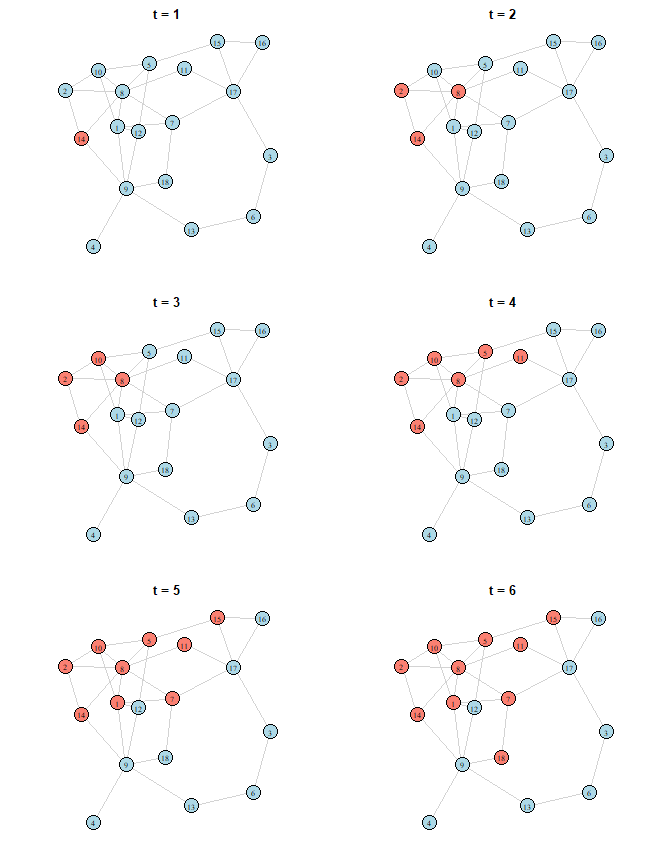

```r
E(g2)$color <- "lightgray"

par(mfrow=c(3, 2), mar=c(0, 0, 0, 0) + 2)

for (i in seq_len(6)) {

  data_i <- subset(data, .time==i)

  V(g2)$color <- ifelse(data_i$infected, "salmon", "lightblue")

  set.seed(124)
  plot(g2,
       vertex.label.cex=0.8,
       vertex.label.color="black",
       size=1,
       main=paste0("t = ", i),
       layout=layout_nicely(g2),
       margin=0)
}
```

The infection started with only individual 14 being infected (the index case). From there it spread immediately to individuals 2 and 8 and continued from there, as an actual infection might have. It would of course also be possible to make the probability generating function more realistic, or to add further variables such as vaccinations.

## Dynamic networks

In all previous examples, the network structure itself never changed, because we only used a single `network()` call defining a static network. Below we extend our approach to the case of *dynamic* networks, that may change over time (possibly as a function of other fixed or time-varying variables).

### Random new networks at each point in time

Let us start with the easiest type of dynamic network that we can imagine: a network structure that changes entirely at every single point in time without any correlation to what it previously looked like or to what has happened to the individuals in it. We can do this using almost the same code that we used earlier. The main difference for any situation in which dynamic networks should be used is that we need to define a function that generates the network for us. Below is one possibility:

```r
gen_network <- function(n_sim) {
  igraph::sample_gnm(n=n_sim, m=30)
}
```

The only requirement for the function is that it has a single named argument called `n_sim`, which controls the size of the network (number of vertices in it). In the function above, this argument is simply passed to the `sample_gnm()` function of the `igraph` package that we already used earlier. We can now use almost the same code as we did before to generate data using this function:

```r
dag <- empty_dag() +
  node_td("n_infected_neighbors", type="identity",
          formula= ~ net(sum(infected_event), na=0), kind="data") +
  node_td("infected", type="time_to_event", event_duration=Inf,
          immunity_duration=Inf, parents=("n_infected_neighbors"),
          prob_fun=prob_infection) +
  network_td("net1", net=gen_network)

set.seed(1335)

sim <- sim_discrete_time(dag, n_sim=18, max_t=6, save_states="all",
                         save_networks=TRUE)
data <- sim2data(sim, to="long")
head(data)
```

```
#> Key: <.id, .time>
#>      .id .time n_infected_neighbors infected
#>    <int> <int>                <num>   <lgcl>
#> 1:     1     1                    0    FALSE
#> 2:     1     2                    0    FALSE
#> 3:     1     3                    1    FALSE
#> 4:     1     4                    1     TRUE
#> 5:     1     5                    3     TRUE
#> 6:     1     6                    5     TRUE
```

The only difference to the previous code is that we used `network_td()` instead of `network()`, passing the function to the `net` argument. Everything else is the same. The code to visualize the spread of the disease is also very similar, with the one change being that we now have one network per slide (saved in the `sim` object because we set `save_networks=TRUE`):

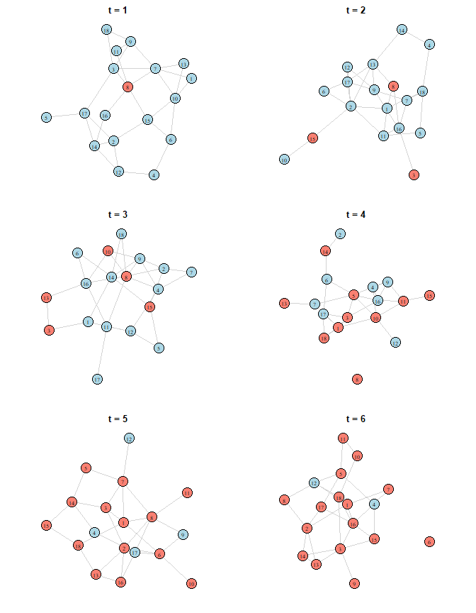

```r
par(mfrow=c(3, 2), mar=c(0, 0, 0, 0) + 2)

for (i in seq_len(6)) {

  data_i <- subset(data, .time==i)
  g_i <- sim$past_networks[[i]]$net1$net

  E(g_i)$color <- "lightgray"
  V(g_i)$color <- ifelse(data_i$infected, "salmon", "lightblue")

  set.seed(124)
  plot(g_i, vertex.label.cex=0.8,
       vertex.label.color="black",
       size=1,
       main=paste0("t = ", i),
       layout=layout_nicely(g_i),
       margin=0)
}
```

Here, the simulation starts out with individuals 8 being infected, while being connected to individuals 3, 7, 11, 15 and 16 at $t = 1$. This individual then spread the infection to individuals 3 and 15, as can be seen at $t = 2$. However, the network has changed completely at this point. Now the individuals are connected to others, spreading the infection even further to those they are connected with now. This repeats until almost everyone (except individuals 4 and 12) are infected. Note that it makes a significant difference in which order the `node_td()` and `network_td()` calls are added, as in usual simulations using `sim_discrete_time()`.

### Adjusting a network over time

Lets move to a more useful example, in which the network is initiated once at the beginning and changed slightly over time instead of re-drawing it every time. As an example, we will again extend the earlier infectious disease example. In this new example, the government is trying to contain the epidemic by isolating infected individuals. The act of isolation in this context means, that an infected individual is put under quarantine and is not allowed to have any contact to other individuals, which translates to removing all connections the infected individual has in the network. We will assume that the government is able to perfectly enforce the isolation, but that it is a little slow in doing so. Only after one full day of being sick does the government realize that an individual is infected.

First, we have to adjust the `gen_network()` function. We will use the following code:

```r
gen_network <- function(n_sim, sim_time, network, data) {

  if (sim_time==0) {
    return(igraph::sample_gnm(n=n_sim, m=23))
  }

  rm_edges <- data$.id[data$infected_event==TRUE &
                       data$infected_time_since_last > 0]

  if (length(rm_edges) > 0) {
    rm_edges <- do.call(c, incident_edges(network, rm_edges))
    g_new <- delete_edges(network, rm_edges)
  } else {
    g_new <- network
  }
  return(g_new)
}
```

There is a few lines of obscure code here, but generally what the function does is really simple. At $t = 0$ it simply generates a random graph using `sample_gnm()`. From $t = 1$ on it simply checks whether any person is infected and isolates them, by deleting their connections and returning the adjusted network. By adding the time-dependent networks after the time-dependent nodes in the `DAG`, we ensure that it is updated only after all nodes of a day have been generated. Because the `time_since_last` counter of the `infected` node starts at 0 using `data$infected_time_since_last > 0` ensures that each individual has one full day to spread the infection. Note that the arguments `sim_time`, `network` and `data` are automatically passed internally. `sim_time` is the current simulation time, `network` is the current state of the network and `data` is the current state of the data.

We can now re-use almost the same `DAG` definition from earlier:

```r
dag <- empty_dag() +
  node_td("n_infected_neighbors", type="identity",
          formula= ~ net(sum(infected_event), na=0), kind="data") +
  node_td("infected", type="time_to_event", event_duration=Inf,
          immunity_duration=Inf, parents=("n_infected_neighbors"),
          prob_fun=prob_infection, time_since_last=TRUE) +
  network_td("net1", net=gen_network, create_at_t0=TRUE)
```

The only difference to before is that we actively set `create_at_t0=TRUE` so that the network gets created before time-dependent processing starts (so we have a network to adjust at $t = 1$) and that we set `time_since_last=TRUE` in the `infected` node to track the time since the original infection, because we need that information in the network generating function. Lets run the simulation again:

```r
set.seed(13354)

sim <- sim_discrete_time(dag, n_sim=18, max_t=6, save_states="all",
                         save_networks=TRUE)
data <- sim2data(sim, to="long")
head(data)
```

```
#> Key: <.id, .time>
#>      .id .time n_infected_neighbors infected infected_time_since_last
#>    <int> <int>                <num>   <lgcl>                    <num>
#> 1:     1     1                    0    FALSE                       NA
#> 2:     1     2                    1    FALSE                       NA
#> 3:     1     3                    1     TRUE                        0
#> 4:     1     4                    0     TRUE                        1
#> 5:     1     5                    0     TRUE                        2
#> 6:     1     6                    0     TRUE                        3
```

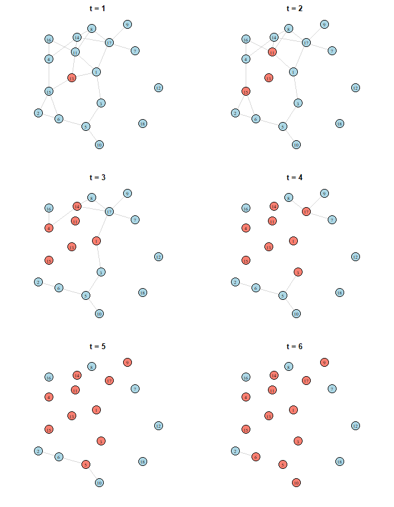

```r
par(mfrow=c(3, 2), mar=c(0, 0, 0, 0) + 2)

layout_g <- layout_nicely(sim$past_networks[[1]]$net1$net)

for (i in seq_len(6)) {

  data_i <- subset(data, .time==i)
  g_i <- sim$past_networks[[i]]$net1$net

  E(g_i)$color <- "lightgray"
  V(g_i)$color <- ifelse(data_i$infected, "salmon", "lightblue")

  set.seed(124)
  plot(g_i, vertex.label.cex=0.8,
       vertex.label.color="black",
       size=1,
       main=paste0("t = ", i),
       layout=layout_g,
       margin=0)
}
```

As can be seen, due to the timely delay of the isolation, the infection is still able to spread, but it cannot reach all individuals. Near the end of the simulation, practically all connections are removed, making it impossible for the infection to spread further. This is by no means a realistic example, but it showcases how changing networks might be utilized in this package.

This simulation could easily be extended to make the isolation non-permanent, by re-adding the removed connections after a pre-defined duration, or could be even further extended by adding vaccinations or other variables. Additionally, although not shown in this vignette, it would of course also be possible to use the other features shown for regular simulations (weighted or directed networks, multiple networks, etc.) in discrete-time simulation as well.

# Discussion

Networks-based simulations offer an additional amount of flexibility in specifying data generation processes (DGP) that is usually not included in general-purpose simulation software. By making cross-individual dependencies possible through one or multiple networks and allowing those to also be influenced by individual-level variables, almost any kind of data can be generated. The `simDAG` package offers a simple and consistent syntax to perform such simulations. Network dependencies are fully integrated into the enhanced `formula` syntax through the `net()` function, which hopefully makes the barrier to use this methodology a lot less daunting for potential users.

Despite the great flexibility offered by this approach, it is used quite infrequently in practice. The preprint published by Sofrygin, Neugebauer, and van der Laan (2017) did not gather a lot of attention, even though they also offered a clean and powerful implementation of the method through the `simcausal` (Sofrygin, van der Laan, and Neugebauer 2017) package (which heavily inspired the presented `simDAG` implementation). I suspect that the main reason for this is that there are only few statistical models designed to actually analyze data with such complex DGPs. Despite recent advancements, the combination of network science and causal inference is still in its infancy, as has been pointed out by others (Ogburn et al. 2024; VanderWeele and An 2013; An, Beauvile, and Rosche 2022). I hope that this implementation will make future investigations into this subject easier or at least more convenient to methodological researchers.

# References

An, Weihua, Roberson Beauvile, and Benjamin Rosche. 2022. “Causal Network Analysis.” *Annual Reviews of Sociology* 48: 23–41. https://doi.org/10.1146/annurev-soc-030320-102100.

Danon, Leon, Ashley P. Ford, Thomas House, Chris P. Jewell, Matt J. Keeling, Gareth O. Roberts, Joshua V. Ross, and Matthew C. Vernon. 2011. “Networks and the Epidemiology of Infectious Disease.” *Interdisciplinary Perspectives on Infectious Diseases* 16. https://doi.org/10.1155/2011/284909.

Denz, Robin, and Nina Timmesfeld. 2026. “Simulating Complex Cross-Sectional and Longitudinal Data Using the simDAG R Package.” *Journal of Statistical Software* 116 (2): 1–40. https://doi.org/10.18637/jss.v116.i02.

Ogburn, Elizabeth L., Oleg Sofrygin, Iván Díaz, and Mark J. van der Laan. 2024. “Causal Inference for Social Network Data.” *Journal of the American Statistical Association* 119 (545): 597–611. https://doi.org/10.1080/01621459.2022.2131557.

Sofrygin, Oleg, Romain Neugebauer, and Mark J. van der Laan. 2017. “Conducting Simulations in Causal Inference with Networks-Based Structural Equation Models.” arXiv prepring. https://doi.org/10.48550/arXiv.1705.10376.

Sofrygin, Oleg, Mark J. van der Laan, and Romain Neugebauer. 2017. “Simcausal r Package: Conducting Transparent and Reproducible Simulation Studies of Causal Effect Estimation with Complex Longitudinal Data.” *Journal of Statistical Software* 81 (2): 1–47. https://doi.org/10.18637/jss.v081.i02.

VanderWeele, Tyler J., and Weihua An. 2013. “Social Networks and Causal Inference.” In *Handbook of Causal Analysis for Social Research*, edited by Stephen L. Morgan. Dordrecht: Springer Science + Business Media. https://doi.org/10.1007/978-94-007-6094-3.